# PM 616 HW1 due 9/14

Sylvia Shen

2022-09-07

# (a)

## Exploratory data analysis

The titanic data includes 1309 subjects (891 in training set and 418 in testing set). There are in total 12 variables: the survival status (`Survival`), passenger class (`pclass`), first and last name of the passenger (`name`), sex, age, the number of siblings/spouses aboard (`sibsp`), the number of parents/children aboard (`parch`), ticket number (`ticket`), fare, cabin ID, and the port of embarkation (`Embarked`).

```r
# dim( titanic_train) ## 891 12
# head(titanic_train)
# unique(titanic_train$Name) %>% length()

## table one
cat_vars = c("Pclass", "Sex", "SibSp", "Parch", "Embarked")
tblone = CreateTableOne(vars = c("Age", "Fare", cat_vars),
               factorVars = cat_vars,
               data = titanic_train,
               strata = "Survived",
               includeNA = TRUE, test = FALSE, addOverall =TRUE)
print(tblone, missing = TRUE)
```

```
##                   Stratified by Survived
##                    Overall       0             1             Missing
##   n                  891           549           342
##   Age (mean (SD))  29.70 (14.53) 30.63 (14.17) 28.34 (14.95) 19.9
##   Fare (mean (SD)) 32.20 (49.69) 22.12 (31.39) 48.40 (66.60)  0.0
##   Pclass (%)                                                  0.0
##      1               216 (24.2)     80 (14.6)    136 (39.8)
##      2               184 (20.7)     97 (17.7)     87 (25.4)
##      3               491 (55.1)    372 (67.8)    119 (34.8)
##   Sex = male (%)     577 (64.8)    468 (85.2)    109 (31.9)   0.0
##   SibSp (%)                                                   0.0
##      0               608 (68.2)    398 (72.5)    210 (61.4)
##      1               209 (23.5)     97 (17.7)    112 (32.7)
##      2                28 ( 3.1)     15 ( 2.7)     13 ( 3.8)
##      3                16 ( 1.8)     12 ( 2.2)      4 ( 1.2)
##      4                18 ( 2.0)     15 ( 2.7)      3 ( 0.9)
##      5                 5 ( 0.6)      5 ( 0.9)      0 ( 0.0)
##      8                 7 ( 0.8)      7 ( 1.3)      0 ( 0.0)
##   Parch (%)                                                   0.0
##      0               678 (76.1)    445 (81.1)    233 (68.1)
##      1               118 (13.2)     53 ( 9.7)     65 (19.0)
##      2                80 ( 9.0)     40 ( 7.3)     40 (11.7)
##      3                 5 ( 0.6)      2 ( 0.4)      3 ( 0.9)
##      4                 4 ( 0.4)      4 ( 0.7)      0 ( 0.0)
##      5                 5 ( 0.6)      4 ( 0.7)      1 ( 0.3)
##      6                 1 ( 0.1)      1 ( 0.2)      0 ( 0.0)
##   Embarked (%)                                                0.0
##                        2 ( 0.2)      0 ( 0.0)      2 ( 0.6)
##      C               168 (18.9)     75 (13.7)     93 (27.2)
##      Q                77 ( 8.6)     47 ( 8.6)     30 ( 8.8)
##      S               644 (72.3)    427 (77.8)    217 (63.5)
```

From the table above, we first noticed that fare and passenger class are quite different between the two groups; individuals who paid higher fare and in the first class are more likely to survive. In addition, only 109(18.9%) of the males survived whereas 233(74.2%) of the females managed to get out of the Titanic.

Passenger name and ticket number can be viewed as duplicated identifiers such as passenger ID. Therefore, we drop passenger name and ticket number, and keep passenger ID to be the unique identifier of each data entry. There are in total 687(77.1%) individuals in the training data that does not have available `Cabin` information. For other individuals that have `Cabin` recorded, most `Cabin` numbers are unique to every individual. Therefore, we decided to drop the variable `Cabin` as it does not provide useful grouping information in this data.

There are also 2 individuals in the training set that does not have the port of embarkation (`Embarked`) recorded. In addition, there are 177 missing values in `Age`. Age is potentially an important predictor because people’s mobility usually decreases as age increases and the family size of the elderly might be different from those in their 20s, which could all be affecting their survival probability. Possible approaches to impute missing age values include: deterministic imputation with mean or median of all available ages in this data; random imputation by adding random errors to the mean or median; predicting age by building a model of age with other variables in this data set. The first two methods might be introducing additional bias to the final model. The third approach requires multiple imputations to minimize potential bias. In this analysis, we decided not to perform any imputation on age to avoid introducing additional bias in the final model. Therefore, we exclude these 179 individuals and continue analysis with the remaining 712 samples. In the testing set, we will apply the same exclusion criteria.

```r
## data wrangling
## use fastDummies::dummy_cols to covert categorical to dummy

titanic_train_cleaned = titanic_train %>%
  select(-c(Name, Ticket, Cabin)) %>%
  filter(Embarked != "", !is.na(Age)) %>%
  mutate(Survived = factor(Survived, levels = c(0,1), labels = c("Died", "Survived")),
         Sex = ifelse(Sex == "male", 1, 0)) %>%
  fastDummies::dummy_cols(select_columns = c("Pclass","Embarked"),
                          remove_first_dummy = TRUE,
                          remove_selected_columns = TRUE)

titanic_test_cleaned = titanic_test %>%
  select(-c(Name,Ticket, Cabin)) %>%
  filter(Embarked != "", !is.na(Age), !is.na(Fare)) %>%
  mutate(Sex = ifelse(Sex == "male", 1, 0)) %>%
  fastDummies::dummy_cols(select_columns = c("Pclass","Embarked"),
                          remove_first_dummy = TRUE,
                          remove_selected_columns = TRUE)

# dim(titanic_train_cleaned)
# dim(titanic_test_cleaned)
```

## Prediction models

The original test set in the `titanic` data does not provide the survival status. To avoid over-fitting, I split `titanic_train` further into an actual training set (571 samples; 80%) and a testing test (141 samples; 20%) for comparing model performance and also the selection of best performing model on this data. `Titani_test` will be treated as an external validation set for validating the performance of my final model.

```r
## partition titanic_train
set.seed(321)
rowTrain <- createDataPartition(y = titanic_train_cleaned$Survived, p = 0.8, list = FALSE)

## set up cross validation parameters
ctrl = trainControl(method = "repeatedcv",
                    repeats = 5,
                    summaryFunction = twoClassSummary,
                    classProbs = TRUE)
```

### GLM

```r
set.seed(123)
model.glm = train(x = titanic_train_cleaned[rowTrain, 3:ncol(titanic_train_cleaned)],
                  y = titanic_train_cleaned$Survived[rowTrain],
                  method = "glm",
                  metric = "ROC",
                  trControl = ctrl)
```

### Regularized GLM

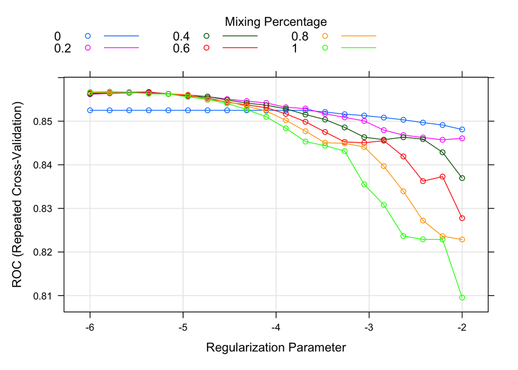

```r
glmnGrid = expand.grid(.alpha = seq(0, 1, length = 6),
                       .lambda = exp(seq(-6, -2, length = 20)))

set.seed(123)
model.glmn = train(x = titanic_train_cleaned[rowTrain, 3:ncol(titanic_train_cleaned)],
                  y = titanic_train_cleaned$Survived[rowTrain],
                  method = "glmnet",
                  tuneGrid = glmnGrid,
                  metric = "ROC",
                  trControl = ctrl)
plot(model.glmn, xTrans = function(x) log(x))
```

### Naive Bayes

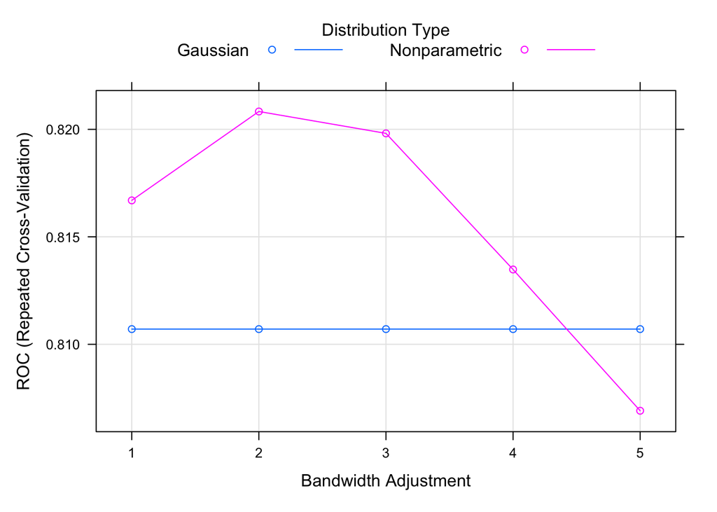

```r
set.seed(123)
nbGrid = expand.grid(usekernel = c(FALSE, TRUE) , ## Gaussian density, non-para kernel
                     fL = 1,
                     adjust = seq(1,5,by=1))
model.nb = train(x = titanic_train_cleaned[rowTrain, 3:ncol(titanic_train_cleaned)],
                  y = titanic_train_cleaned$Survived[rowTrain],
                  method = "nb",
                  tuneGrid = nbGrid,
                  metric = "ROC",
                  trControl = ctrl)
plot(model.nb)
```

### KNN

```r
set.seed(123)
model.knn =  train(x = titanic_train_cleaned[rowTrain, 3:ncol(titanic_train_cleaned)],
                  y = titanic_train_cleaned$Survived[rowTrain],
                  method = "knn",
                  preProcess = c("center","scale"),
                  tuneGrid = data.frame(k = seq(1,60,by=2)),
                  trControl = ctrl)
```

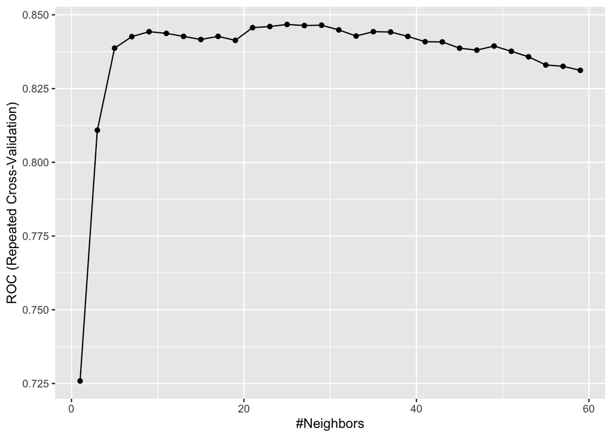

```r
ggplot(model.knn)
```

### AUC on the held-out set

```r
## AUC on test set
glm.pred.prob = predict(model.glm, newdata = titanic_train_cleaned[-rowTrain,3:ncol(titanic_train_cleaned)], type = "prob")[,2]
glmn.pred.prob = predict(model.glmn, newdata = titanic_train_cleaned[-rowTrain,3:ncol(titanic_train_cleaned)], type = "prob")[,2]
nb.pred.prob = predict(model.nb, newdata = titanic_train_cleaned[-rowTrain,3:ncol(titanic_train_cleaned)], type = "prob")[,2]
knn.pred.prob = predict(model.knn, newdata = titanic_train_cleaned[-rowTrain,3:ncol(titanic_train_cleaned)], type = "prob")[,2]

roc.glm = roc(titanic_train_cleaned$Survived[-rowTrain], glm.pred.prob)
roc.glmn = roc(titanic_train_cleaned$Survived[-rowTrain], glmn.pred.prob)
roc.nb = roc(titanic_train_cleaned$Survived[-rowTrain], nb.pred.prob)
roc.knn = roc(titanic_train_cleaned$Survived[-rowTrain], knn.pred.prob)
```

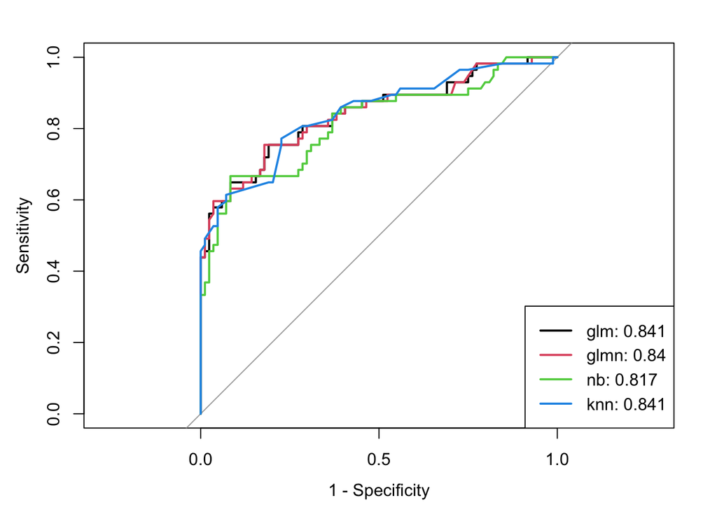

```r
auc = c(roc.glm$auc[1], roc.glmn$auc[1], roc.nb$auc[1], roc.knn$auc[1])

plot(roc.glm, legacy.axes = TRUE)
plot(roc.glmn, col = 2, add = TRUE)
plot(roc.nb, col = 3, add = TRUE)
plot(roc.knn, col = 4, add = TRUE)
modelNames = c("glm","glmn","nb","knn")
legend("bottomright", legend = paste0(modelNames, ": ", round(auc,3)), col = 1:6, lwd = 2)
```

From the plot above, we can see that KNN, GLM, and regularized GLM has similar AUC on the held-out test set (0.841, 0.841, and 0.84 respectively), followed by the Naive Bayes model (0.817).

### Accuracy on the held-out set

```r
## accuracy on test set
glm.pred.accu = predict(model.glm, newdata = titanic_train_cleaned[-rowTrain,3:ncol(titanic_train_cleaned)])
glmn.pred.accu = predict(model.glmn, newdata = titanic_train_cleaned[-rowTrain,3:ncol(titanic_train_cleaned)])
nb.pred.accu = predict(model.nb, newdata = titanic_train_cleaned[-rowTrain,3:ncol(titanic_train_cleaned)])
knn.pred.accu = predict(model.knn, newdata = titanic_train_cleaned[-rowTrain,3:ncol(titanic_train_cleaned)])

accu.glm = mean(titanic_train_cleaned$Survived[-rowTrain] == glm.pred.accu)
accu.glmn = mean(titanic_train_cleaned$Survived[-rowTrain] == glmn.pred.accu)
accu.nb = mean(titanic_train_cleaned$Survived[-rowTrain] == nb.pred.accu)
accu.knn = mean(titanic_train_cleaned$Survived[-rowTrain] == knn.pred.accu)

cat("glm test set accuracy = ", round(accu.glm,4))
```

```
## glm test set accuracy =  0.7801
```

```r
cat("\nglmb test set accuracy = ", round(accu.glmn,4))
```

```
##
## glmb test set accuracy =  0.7872
```

```r
cat("\nnb test set accuracy = ", round(accu.nb,4))
```

```
##
## nb test set accuracy =  0.7872
```

```r
cat("\nknn test set accuracy = ", round(accu.knn,4))
```

```
##
## knn test set accuracy =  0.7943
```

KNN achieved the highest accuracy (0.794) on the held-out set among these four models. By considering both AUC and accuracy, I chose KNN as the final prediction model.

### ANN

In addition to the four supervised learning models above, I also tried an ANN with one hidden layer with ReLU activation function. However, its accuracy on the held-out set did not beat the KNN model.

```r
## ANN model

normalizer <- layer_normalization(axis = -1L)
```

```
## Loaded Tensorflow version 2.9.2
```

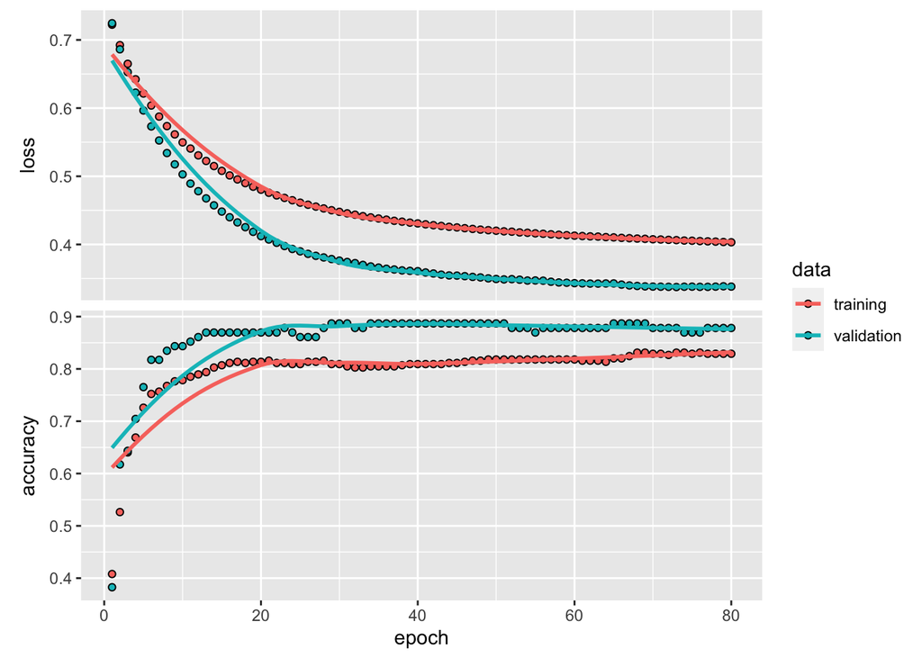

```r
normalizer %>% adapt(as.matrix(titanic_train_cleaned[rowTrain, 3:ncol(titanic_train_cleaned)]))


network <- keras_model_sequential() %>%
  normalizer() %>%
  layer_dense(64, activation = "relu") %>%
  layer_dense(1, activation = "sigmoid")


network %>% compile(
  optimizer='adam',
  loss='binary_crossentropy',
  metrics='accuracy'
)

history = network %>% fit(as.matrix(titanic_train_cleaned[rowTrain, 3:ncol(titanic_train_cleaned)]),
                          as.matrix(ifelse(titanic_train_cleaned[rowTrain, 2] == "Survived", 1,0)),
                          validation_split = 0.2,
                             epochs = 80, batch_size = 100
                             )



plot(history)
```

```r
network %>% evaluate(
  as.matrix(titanic_train_cleaned[-rowTrain, 3:ncol(titanic_train_cleaned)]),
  as.matrix(ifelse(titanic_train_cleaned[-rowTrain, 2] == "Survived", 1,0)),
  verbose = 0
)
```

```
##      loss  accuracy
## 0.4297789 0.7943262
```

### Output final prediction

```r
## output final prediction
knn.pred.test = predict(model.knn, newdata = titanic_test_cleaned[,2:ncol(titanic_test_cleaned)])
test.pred.tbl = data.frame(PassengerId = titanic_test_cleaned$PassengerId,
                           PredClass = knn.pred.test) %>%
  right_join(titanic_test, by = "PassengerId") %>%
  select(c(PassengerId,PredClass))

write.csv(test.pred.tbl,
          file = "test_set_prediction.csv", quote = F, row.names = F)
```

# (b)

*There are many analysis demonstrations of this dataset online, both in R and Python. Do not look at them. Try to get as much as possible yourself. Then look at other people’s solutions online (by just googling). Summarize what you have learned from them, and if you did something better than most of online demonstrations, brieﬂy highlight them.*

In most of the popular solutions, missing values in `Age` are imputed in various ways, including: (1) imputing the mean or median of all available `Age` in the training data and adding a small random noise; (2) build a model to predict age as a continuous variable based on `Sex`, `Pclass` and other variables correlated with age; (3) categorize `Age` into discrete categories (such as <10, 10-25, 25-60 and >60) and then build a model to predict age category. In some solutions, they also imputed the 2 missing values in `Embarked`by the most common category “S”. If time and resource permit, I can improve my model by performing multiple imputation on `Age` and `Embarked` and perform a sensitivity analysis of how sensitive the final model is to the imputation in missing age.

The most comprehensive solution I saw considered all sorts of classification models: logistic regression, KNN, SVM, Naive Bayes, Decision Tree, Random Forest, ANN, Relevance Vector Machine. However, I only tried logistic regression, KNN, NB, and one configuration of ANN. For future real-life data analysis, I think it should be standard practice to benchmark all the common methods that are appropriate for the outcome type. And then fine-tune the top performing models before we decide on the final prediction.